# Module 4 Project, Part A: Check Your Numbers

These numbers come from one complete run of the project with a fixed random seed. Compare them with yours for the same order of magnitude, the same conclusions, the same first digit or two. They are not an answer key: the exam asks about *your* project.

What should match, and how closely:

- **Exact values** do not depend on random numbers and should match to every digit shown: everything except the bootstrap SE in A.4.
- **The bootstrap SE** varies from run to run. Yours should agree with this one to about two significant digits.

# Part A

## A.1

The histogram of library sizes and the method of moments estimate.

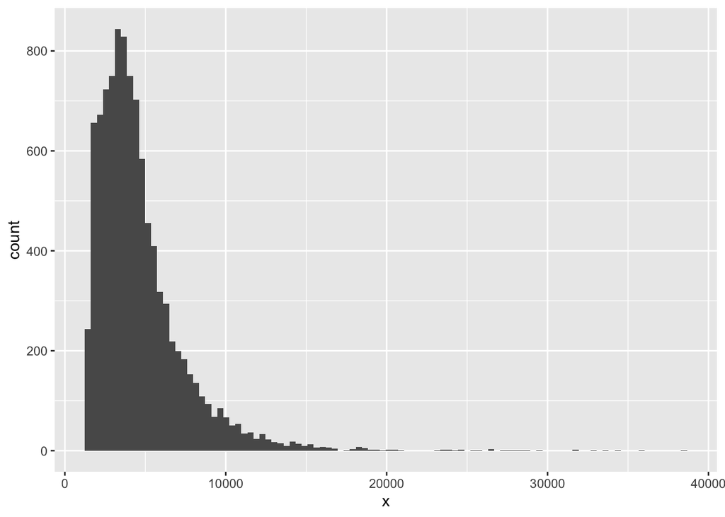

```
## [1] 2.684622
```

Every Newton iterate from the method of moments estimate.

```
## [1] 2.684622 3.433216 3.717452 3.744101 3.744301 3.744301 3.744301
```

$\hat\alpha$ from `uniroot`, then the number of bisection steps.

```
## [1] 3.744301
```

```
## [1] 38
```

## A.2

The start whose first step lands at 0, beside $\hat\alpha$, then Newton from 0.1 below and 0.1 above it.

```
##   a_star     ahat
## 7.412727 3.744301
```

```
##  [1] 7.3127274 0.2014707 0.3690665 0.6620763 1.1537054 1.9002751 2.8048560
##  [8] 3.4997329 3.7277046 3.7442248 3.7443013 3.7443013 3.7443013
```

```
## [1]  7.5127274 -0.2070451        NaN
```

Newton from 10.

```
## [1] 10.00000 -7.15078      NaN
```

Newton with step halving from 10.

```
## [1] 10.000000  5.712305  4.189884  3.689163  3.743457  3.744301  3.744301
## [8]  3.744301
```

## A.3

Newton for the 0.99 quantile from $\bar x$, then `qgamma`.

```
##  [1]  4655.914  7253.557  9130.900 10605.298 11567.100 11935.553 11980.079
##  [8] 11980.658 11980.658 11980.658
```

```
## [1] 11980.66
```

The density at 40,000, then Newton from there.

```
## [1] 2.685126e-14
```

```
## [1]  4.00000e+04 -3.72422e+11          Inf          NaN
```

The two cutoffs, then the number of cells above each.

```
##    gamma      99%
## 11980.66 14675.00
```

```
## gamma  data
##   235    99
```

## A.4

The information SE.

```
## [1] 0.0508465
```

The bootstrap SE from 1,000 resamples.

```
## [1] 0.06112007
```

The information SE from both parameters, then the three SEs side by side.

```
## [1] 0.0508465
```

```
## information    sandwich   bootstrap
##  0.05084650  0.06353837  0.06112007
```